# What are the attitudes of ETH students towards food waste reduction strategies such as food donation programs, composting and reducing food purchased, and how do these influence their food waste behaviour?

A Capstone Project of the Course ‘Research beyond the Lab’

Author

Affiliation

Julia Holenstein

[ETH Zurich](https://ethz.ch/de.html)

Published

June 6, 2024

```r
library(tidyverse)
library(gt)
library(gtsummary)
library(knitr)
library(DT)
library(kableExtra)
library(ggplot2)
library(ggthemes)
```

```r
data_processed <- read_rds("/cloud/project/data/processed/data_processed.rds")
```

# Introduction

This project investigated the attitudes of students towards food waste reduction strategies at ETH mensae and how these would influence their behavior. This project is oriented specifically towards ETH mensae, since UZH has a different caterer in their mensae, thus their food waste reduction strategies differ from ETH mensae.

Although it has been shown that most of the food waste in Switzerland is generated from private households (Beretta et al. (2013)), the food waste behavior of the mensae is still interesting to investigate, since a lot of students eat the food from the mensa instead of preparing it in their private household.

There are several strategies in place at ETH which aim to make the catering more sustainable (“Projekt Nachhaltige Gastronomie” (n.d.)). Almost all of them are targeted towards using certified or sustainable products. Food waste is aimed to be reduced to less than 5% of each menu.

# Methods

The research question has been formulated using the PICOT and FINER guidelines (Fandino (2019)). In order to collect the data, a Google Forms was created and distributed online as well as using a QR-code in order to receive as many answers as possible. The data was collected during one week, and the participants come from various courses of studies.

# Results

### Food Waste in General

All participants were asked to rate how concerned they are about food waste in general, on a scale from one to five. One means ‘not at all concerned’ while five means ‘extremely concerned’. In Table 1, we see how concerned the participants are towards food waste in general. Food waste appears to be a relevant topic, independent of the gender.

```r
concern_mean <- data_processed |>
  filter(!is.na(concern_value)) |>
  group_by(gender) |>
  summarise(
    Mean = round(mean(concern_value, na.rm = TRUE), 2),
    "Standard Deviation" = round(sd(concern_value, na.rm = TRUE), 2),
    "Number of Participants" = n()
  ) |>
  rename(Gender = gender) |>
  add_row(Gender = "Total",
          Mean = round(mean(data_processed$concern_value, na.rm = TRUE), 2),
          "Standard Deviation" = round(sd(data_processed$concern_value, na.rm = TRUE), 2),
          "Number of Participants" = sum(!is.na(data_processed$concern_value)))


concern_mean |>
  kable() |>
  kable_styling(latex_options = c("striped", "scale_down"), full_width = FALSE) |>
  row_spec(row = nrow(concern_mean), bold = TRUE, hline_after = 2.5)
```

Table 1: Participants’ concern towards food waste in general, on a scale from one to five

| Gender | Mean | Standard Deviation | Number of Participants |
| --- | --- | --- | --- |
| Female | 4.29 | 0.49 | 7 |
| Male | 4.33 | 0.89 | 12 |
| Total | 4.32 | 0.75 | 19 |

If, however, we look at how much the participants of the survey know about the food waste reduction strategies of ETH mensae, as visible in Table 2, we notice that there is a lot of room for improvement for ETH to educate about how they try to limit their food waste. Participants were asked to rate their knowledge on a scale from one to five, one meaning ‘I have no idea’ and five meaning ‘I am an expert’.

```r
knowledge_mean <- data_processed |>
  filter(!is.na(knowledge_value)) |>
  summarise(
    Mean = round(mean(knowledge_value, na.rm = TRUE), 2),
    "Standard Deviation" = round(sd(knowledge_value, na.rm = TRUE), 2),
    "Number of Participants" = n()
  )

kable(knowledge_mean)
```

Table 2: Participants’ knowledge of ETH food waste reduction strategies, on a scale of one to five

| Mean | Standard Deviation | Number of Participants |
| --- | --- | --- |
| 1.79 | 1.03 | 19 |

### Willingness to pay

#### Leftovers-Meal

There are several strategies already in practice about how to limit food waste, although ETH recently changed a lot of their mensa-rules. Contrary to ETH, UZH includes a menu option ‘foifer’, which consists of leftover food from the day before. It is cheaper than the other meal options, and available as long as there is still food. The price is 5CHF.

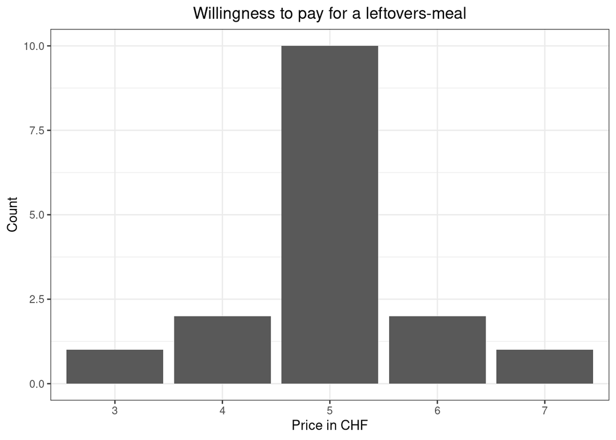

Figure 1: Participants’ willingness to pay fo a leftovers-meal

```r
data_processed$buy_leftovers_value <- as.factor(data_processed$buy_leftovers_value)

# Count occurrences
count_price_leftover <- data_processed |>
  count(buy_leftovers_value)

ggplot(count_price_leftover, aes(x = buy_leftovers_value, y = n)) +
  geom_col() +
  scale_x_discrete(limits = levels(data_processed$buy_leftovers_value)) +
  xlab("Price in CHF") +
  ylab("Count") +
  ggtitle("Willingness to pay for a leftovers-meal") +
  theme_bw() +
  theme(plot.title = element_text(hjust = 0.5))
```

#### Larger Portion

Larger portion sizes are often handled differently, depending on the mensae. At Polymensa, you could ask for a larger size but you could also get a free refill if you were still hungry after finishing the meal. In my opinion, this made sense since in this case, less customers would prejudiced ask for a larger portion but in the end not finish it. If we look at Figure 2, we see that some participants regularly ask for larger portion sizes, but there is generally hardly any leftover food.

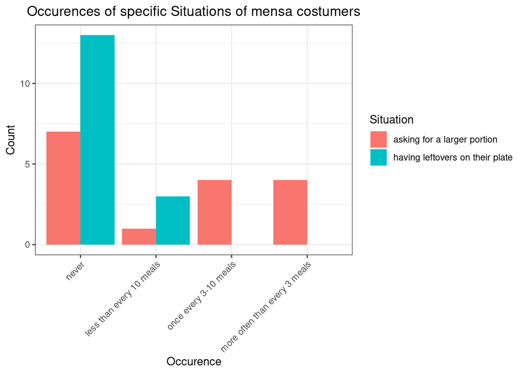

Figure 2: Participants’ habits at mensa

```r
# Count occurrences
count_largeportion <- data_processed |>
  count(largeportion_amount)
count_leftovers <- data_processed |>
  count(leftovers_amount)

# Define order on the x-axis
order_occurence <- c("never", "less than every 10 meals", "once every 3-10 meals", "more often than every 3 meals")

# Create a combined data frame with only the desired values
habits_data_combined <- data.frame(
  Variable = rep(c("having leftovers on their plate", "asking for a larger portion"), each = length(order_occurence)),
  Value = rep(order_occurence, times = 2),
  Count = c(count_leftovers$n[match(order_occurence,
                                    count_leftovers$leftovers_amount)],
            count_largeportion$n[match(order_occurence,
                                       count_largeportion$largeportion_amount)])
  )


# Replace NA with 0 for missing values
habits_data_combined$Count[is.na(habits_data_combined$Count)] <- 0

# Convert Value to factor with desired order
habits_data_combined$Value <- factor(habits_data_combined$Value, levels = order_occurence)

# Plot the data
ggplot(habits_data_combined, aes(x = Value, y = Count, fill = Variable)) +
  geom_col(position = "dodge") +
  xlab("Occurence") +
  ylab("Count") +
  ggtitle("Occurences of specific Situations of mensa costumers") +
  theme_bw() +
  theme(plot.title = element_text(hjust = 0.5)) +
  theme(axis.text.x = element_text(angle = 45, hjust = 1)) +
  guides(fill = guide_legend(title = "Situation"))
```

When we look at the willingness to pay for a larger portion though, less than 50% of participants would be willing to pay for a larger sized portion, and they all would pay no more than a 1-2CHF price increase. Thus it makes sense that ETH changed their price policy at the Archimedes mensa, where they used to charge 3CHF for a larger sized portion.

```r
#This code is only to calculate values used in the text, not printed

pay_for_larger_portion <- sum(data_processed$paymore_largerportion == "Yes",
                              na.rm = TRUE)
# print(pay_for_larger_portion/nrow(data_processed))
```

### Food Options

Lastly, we will take a look at appropriate food options.

Nearly 95% op participants agree that there should always be a vegetarian menu options, while about 66% agree that there should always be a vegan option. Of course it should be considered, that more different food options will lead to more food waste. In Figure 3, we see that most participants would be happy with three different menu options. Since most ETH mensae have at least four different options, this might be a point to improve.

```r
#This code is only to calculate values used in the text, not printed

vegi_yes <- sum(data_processed$vegi_option == "Yes",
                              na.rm = TRUE)
# print(vegi_yes/nrow(data_processed))

vegan_yes <- sum(data_processed$vegan_option == "Yes",
                 na.rm = TRUE)
# print(vegan_yes/nrow(data_processed))
```

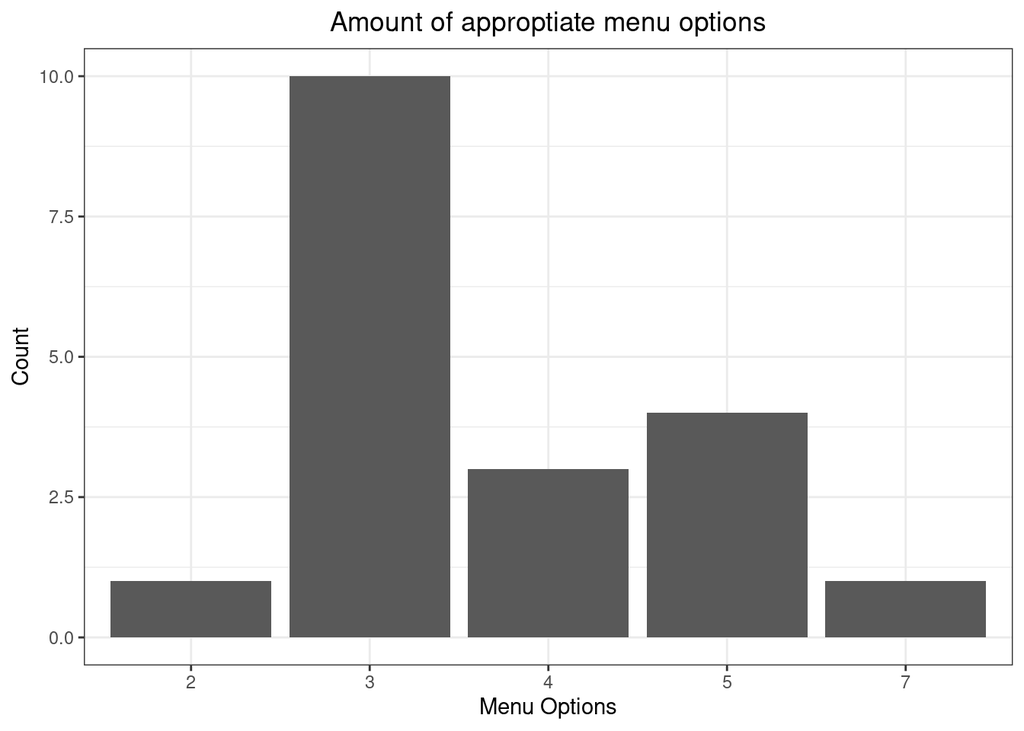

Figure 3: Participants’ Optinion about amount of menu options

```r
data_processed$foodoptions_amount <- as.factor(data_processed$foodoptions_amount)

# Count occurrences
count_foodoptions <- data_processed |>
  count(foodoptions_amount)

ggplot(count_foodoptions, aes(x = foodoptions_amount, y = n)) +
  geom_col() +
  scale_x_discrete(limits = levels(data_processed$foodoptions_amount)) +
  xlab("Menu Options") +
  ylab("Count") +
  ggtitle("Amount of approptiate menu options") +
  theme_bw() +
  theme(plot.title = element_text(hjust = 0.5))
```

# Conclusions

In the following bullet points, the main conclusions of this report are summarized:

- Concern about food waste is high and independent of gender
- Participants have limited knowledge about ET H’s food waste reduction strategies
- Introducing a menu option out of leftovers for CHF5 would be a reasonable option
- It would be enough if ETH had only three different meals on their menu plan, out of which one is vegan and one is vegetarian

## References

Beretta, Claudio, Franziska Stoessel, Urs Baier, and Stefanie Hellweg. 2013. “Quantifying Food Losses and the Potential for Reduction in Switzerland.” *Waste Management*, Special Thematic Issue: Urban Mining, 33 (3): 764–73. https://doi.org/10.1016/j.wasman.2012.11.007.

Fandino, Wilson. 2019. “Formulating a Good Research Question: Pearls and Pitfalls.” *Indian Journal of Anaesthesia* 63 (8): 611–16. https://doi.org/10.4103/ija.IJA_198_19.

“Projekt Nachhaltige Gastronomie.” n.d. Accessed May 23, 2024. https://ethz.ch/de/die-eth-zuerich/nachhaltigkeit/we-are-embarking-on-the-expedition-to-net-zero/projekt-nachhaltige-gastronomie.html.